```python
import pandas as pd
import matplotlib.pyplot as plt
import numpy as np

import datetime as dt
from datetime import date
from dateutil.relativedelta import relativedelta
%matplotlib inline
```

# 1

- Reading a text file and exporting data as an excel file

```python
practice2 = pd.read_csv(r'C:\Users\Rebecca\Downloads\Exercise2.txt', sep='\t')
df = pd.DataFrame(practice2)
xcel = df.to_excel(r'C:\Users\Rebecca\Downloads\practice23.xlsx', index = None)
```

```python
df
```

|  | extrprob | gender | chwgtlb | chwgtoz | chlddob | youthid | parnted | yuthethn | behreg |
| --- | --- | --- | --- | --- | --- | --- | --- | --- | --- |
| 0 | 51.0 | Child gender girl | 8.0 | 1.0 | 18 May 07 | 1001 | Some college | Yes | 2.0 |
| 1 | 44.0 | Child gender girl | 5.0 | 11.0 | 22 Jun 07 | 1002 | Less than 8yrs | Yes | 3.0 |
| 2 | 46.0 | Child gender girl | 7.0 | 0.0 | 01 Jul 07 | 1003 | HS/GED | Yes | 5.0 |
| 3 | 51.0 | Child gender boy | 8.0 | 0.0 | 28 Jun 07 | 1004 | Some college | Yes | 2.0 |
| 4 | 47.0 | Child gender girl | 6.0 | 8.0 | 11 Jun 07 | 1005 | HS/GED | Yes | 4.0 |
| 5 | 59.0 | Child gender girl | 6.0 | 3.0 | 21 Jul 07 | 1006 | HS/GED | Yes | 2.0 |
| 6 | 48.0 | Child gender girl | 7.0 | 12.0 | 14 Jun 07 | 1007 | HS/GED | Yes | 5.0 |
| 7 | 47.0 | Child gender boy | 7.0 | 4.0 | 23 Jun 07 | 1008 | Some college | Yes | 0.0 |
| 8 | 58.0 | Child gender girl | 8.0 | 5.0 | 19 Jul 07 | 1009 | HS/GED | Yes | 1.0 |
| 9 | 54.0 | Child gender boy | 7.0 | 0.0 | 03 Jul 07 | 1010 | HS/GED | Yes | 0.0 |
| 10 | 50.0 | Child gender boy | 6.0 | 8.0 | 26 Jul 07 | 1011 | HS/GED | Yes | 1.0 |
| 11 | 54.0 | Child gender boy | 8.0 | 8.0 | 02 Jul 07 | 1012 | Some college | Yes | 0.0 |
| 12 | 60.0 | Child gender girl | 7.0 | 12.0 | 26 Jul 07 | 1013 | Less than 8yrs | Yes | 0.0 |
| 13 | 43.0 | Child gender girl | 7.0 | 0.0 | 26 Jun 07 | 1014 | Less than 8yrs | Yes | 2.0 |
| 14 | 51.0 | Child gender boy | 8.0 | 14.0 | 16 Jul 07 | 1015 | HS/GED | Yes | NaN |
| 15 | 50.0 | Child gender boy | 8.0 | 14.0 | 05 Jul 07 | 1016 | HS/GED | Yes | 0.0 |
| 16 | 56.0 | Child gender girl | 7.0 | 14.0 | 03 Jul 07 | 1017 | Less than 8yrs | Yes | 7.0 |
| 17 | 43.0 | Child gender boy | 6.0 | 3.0 | 07 Jul 07 | 1018 | HS/GED | Yes | 0.0 |
| 18 | 59.0 | Child gender boy | 9.0 | 23.0 | 08 Aug 07 | 1019 | Less than 8yrs | Yes | 1.0 |
| 19 | 35.0 | Child gender girl | 8.0 | 0.0 | 22 Aug 07 | 1020 | Some college | Yes | 6.0 |
| 20 | 50.0 | Child gender boy | 8.0 | 1.5 | 26 Jul 07 | 1021 | 9-12yr, no diploma | Yes | 2.0 |
| 21 | 55.0 | Child gender girl | 7.0 | 4.5 | 29 Aug 07 | 1022 | 9-12yr, no diploma | Yes | 0.0 |
| 22 | 59.0 | Child gender boy | 6.0 | 0.0 | 04 Aug 07 | 1023 | 9-12yr, no diploma | Yes | 3.0 |
| 23 | 54.0 | Child gender girl | 7.0 | 3.0 | 14 Jul 07 | 1024 | 9-12yr, no diploma | Yes | 5.0 |
| 24 | 74.0 | Child gender girl | 7.0 | 4.0 | 23 Aug 07 | 1025 | 9-12yr, no diploma | Yes | 0.0 |
| 25 | 39.0 | Child gender girl | 8.0 | 3.0 | 21 Aug 07 | 1026 | 9-12yr, no diploma | Yes | 4.0 |
| 26 | 32.0 | Child gender girl | 8.0 | 3.0 | 03 Aug 07 | 1027 | Some college | Yes | 5.0 |
| 27 | 44.0 | Child gender boy | 7.0 | 8.0 | 16 Aug 07 | 1028 | HS/GED | Yes | 1.0 |
| 28 | 48.0 | Child gender girl | 7.0 | 11.0 | 19 Aug 07 | 1029 | HS/GED | Yes | 3.0 |
| 29 | 63.0 | Child gender girl | 7.0 | 3.0 | 18 Jul 07 | 1030 | Some college | Yes | 2.0 |
| ... | ... | ... | ... | ... | ... | ... | ... | ... | ... |
| 377 | 46.0 | Child gender girl | 7.0 | 19.0 | 28 May 08 | 2176 | 9-12yr, no diploma | No | 1.0 |
| 378 | 37.0 | Child gender boy | 7.0 | 8.0 | 29 May 08 | 2177 | HS/GED | No | 3.0 |
| 379 | 54.0 | Child gender girl | 6.0 | 14.0 | 27 Jun 08 | 2178 | 9-12yr, no diploma | Yes | 1.0 |
| 380 | 40.0 | Child gender boy | 6.0 | 15.0 | 04 Jul 08 | 2179 | Less than 8yrs | No | 2.0 |
| 381 | 37.0 | Child gender boy | 7.0 | 3.0 | 12 Jun 08 | 2180 | College degree | No | 5.0 |
| 382 | 66.0 | Child gender boy | 6.0 | 0.0 | 28 May 08 | 2181 | HS/GED | No | 0.0 |
| 383 | 48.0 | Child gender boy | 5.0 | 15.0 | 13 Jul 08 | 2182 | Some college | No | 1.0 |
| 384 | 77.0 | Child gender girl | 8.0 | 9.0 | 29 May 08 | 2183 | Post-graduate | No | 0.0 |
| 385 | 73.0 | Child gender boy | 6.0 | 12.8 | 21 Jul 08 | 2184 | 9-12yr, no diploma | No | 3.0 |
| 386 | 37.0 | Child gender girl | 9.0 | 12.0 | 07 Jul 08 | 2185 | HS/GED | No | 8.0 |
| 387 | 55.0 | Child gender girl | 6.0 | 7.0 | 30 Jun 08 | 2186 | HS/GED | Yes | 2.0 |
| 388 | 46.0 | Child gender boy | 5.0 | 4.0 | 26 Jun 08 | 2187 | HS/GED | No | 1.0 |
| 389 | 63.0 | Child gender girl | 7.0 | 5.5 | 29 May 08 | 2188 | HS/GED | No | 2.0 |
| 390 | 39.0 | Child gender boy | 7.0 | 6.0 | 22 May 08 | 2189 | HS/GED | No | 3.0 |
| 391 | 40.0 | Child gender girl | 5.0 | 1.0 | 28 Jun 08 | 2190 | HS/GED | No | 2.0 |
| 392 | 39.0 | Child gender boy | 6.0 | 7.0 | 18 Jul 08 | 2191 | HS/GED | No | 3.0 |
| 393 | 58.0 | Child gender boy | 7.0 | 0.0 | 24 Jun 08 | 2192 | Some college | Yes | 3.0 |
| 394 | 52.0 | Child gender boy | 6.0 | 0.0 | 24 Jun 08 | 2193 | Some college | No | 3.0 |
| 395 | 42.0 | Child gender girl | NaN | NaN | NaN | 2194 | Some college | No | 0.0 |
| 396 | 68.0 | Child gender girl | 6.0 | 14.0 | 15 Jul 08 | 2195 | Some college | Yes | 3.0 |
| 397 | 48.0 | Child gender boy | 7.0 | 12.0 | 21 Jul 08 | 2196 | 9-12yr, no diploma | No | 1.0 |
| 398 | 52.0 | Child gender girl | 8.0 | 9.0 | 01 Jul 08 | 2197 | Some college | No | 3.0 |
| 399 | 59.0 | Child gender girl | 7.0 | 3.0 | 18 Jul 08 | 2198 | HS/GED | No | 1.0 |
| 400 | 59.0 | Child gender girl | 6.0 | 12.0 | 22 Jul 08 | 2199 | 9-12yr, no diploma | No | 2.0 |
| 401 | 32.0 | Child gender boy | 8.0 | 15.0 | 26 Jul 08 | 2200 | HS/GED | No | 6.0 |
| 402 | 47.0 | Child gender boy | 6.0 | 7.0 | 30 Jul 08 | 2201 | Some college | No | 3.0 |
| 403 | 35.0 | Child gender boy | 8.0 | 8.0 | 27 Jul 08 | 2202 | 9-12yr, no diploma | No | 0.0 |
| 404 | 37.0 | Child gender girl | 7.0 | 9.0 | 23 Jul 08 | 2203 | HS/GED | No | 0.0 |
| 405 | 62.0 | Child gender girl | 6.0 | 11.0 | 28 Jul 08 | 2204 | HS/GED | No | 4.0 |
| 406 | 47.0 | Child gender boy | 7.0 | 6.0 | 22 Jul 08 | 2205 | 9-12yr, no diploma | No | 4.0 |

407 rows × 9 columns

# 2

- Save only the youthid column into a variable in this case its saved in variable youthid
- Drop the youthid column from our dataset and save this new table in a variaale in this case its saved in variable no_youthid and used drop() to remove the column
- We now combine the single youthid column with the dataset we dropped a column from use the concat() function to combine the youthid column and the dataset so that our new table will show the youthid column as the first column in our dataset

```python
youthid = df['youthid']
no_youthid = df.drop(columns = 'youthid')
new_df = pd.concat([youthid, no_youthid], axis = 1)
new_df
```

|  | youthid | extrprob | gender | chwgtlb | chwgtoz | chlddob | parnted | yuthethn | behreg |
| --- | --- | --- | --- | --- | --- | --- | --- | --- | --- |
| 0 | 1001 | 51.0 | Child gender girl | 8.0 | 1.0 | 18 May 07 | Some college | Yes | 2.0 |
| 1 | 1002 | 44.0 | Child gender girl | 5.0 | 11.0 | 22 Jun 07 | Less than 8yrs | Yes | 3.0 |
| 2 | 1003 | 46.0 | Child gender girl | 7.0 | 0.0 | 01 Jul 07 | HS/GED | Yes | 5.0 |
| 3 | 1004 | 51.0 | Child gender boy | 8.0 | 0.0 | 28 Jun 07 | Some college | Yes | 2.0 |
| 4 | 1005 | 47.0 | Child gender girl | 6.0 | 8.0 | 11 Jun 07 | HS/GED | Yes | 4.0 |
| 5 | 1006 | 59.0 | Child gender girl | 6.0 | 3.0 | 21 Jul 07 | HS/GED | Yes | 2.0 |
| 6 | 1007 | 48.0 | Child gender girl | 7.0 | 12.0 | 14 Jun 07 | HS/GED | Yes | 5.0 |
| 7 | 1008 | 47.0 | Child gender boy | 7.0 | 4.0 | 23 Jun 07 | Some college | Yes | 0.0 |
| 8 | 1009 | 58.0 | Child gender girl | 8.0 | 5.0 | 19 Jul 07 | HS/GED | Yes | 1.0 |
| 9 | 1010 | 54.0 | Child gender boy | 7.0 | 0.0 | 03 Jul 07 | HS/GED | Yes | 0.0 |
| 10 | 1011 | 50.0 | Child gender boy | 6.0 | 8.0 | 26 Jul 07 | HS/GED | Yes | 1.0 |
| 11 | 1012 | 54.0 | Child gender boy | 8.0 | 8.0 | 02 Jul 07 | Some college | Yes | 0.0 |
| 12 | 1013 | 60.0 | Child gender girl | 7.0 | 12.0 | 26 Jul 07 | Less than 8yrs | Yes | 0.0 |
| 13 | 1014 | 43.0 | Child gender girl | 7.0 | 0.0 | 26 Jun 07 | Less than 8yrs | Yes | 2.0 |
| 14 | 1015 | 51.0 | Child gender boy | 8.0 | 14.0 | 16 Jul 07 | HS/GED | Yes | NaN |
| 15 | 1016 | 50.0 | Child gender boy | 8.0 | 14.0 | 05 Jul 07 | HS/GED | Yes | 0.0 |
| 16 | 1017 | 56.0 | Child gender girl | 7.0 | 14.0 | 03 Jul 07 | Less than 8yrs | Yes | 7.0 |
| 17 | 1018 | 43.0 | Child gender boy | 6.0 | 3.0 | 07 Jul 07 | HS/GED | Yes | 0.0 |
| 18 | 1019 | 59.0 | Child gender boy | 9.0 | 23.0 | 08 Aug 07 | Less than 8yrs | Yes | 1.0 |
| 19 | 1020 | 35.0 | Child gender girl | 8.0 | 0.0 | 22 Aug 07 | Some college | Yes | 6.0 |
| 20 | 1021 | 50.0 | Child gender boy | 8.0 | 1.5 | 26 Jul 07 | 9-12yr, no diploma | Yes | 2.0 |
| 21 | 1022 | 55.0 | Child gender girl | 7.0 | 4.5 | 29 Aug 07 | 9-12yr, no diploma | Yes | 0.0 |
| 22 | 1023 | 59.0 | Child gender boy | 6.0 | 0.0 | 04 Aug 07 | 9-12yr, no diploma | Yes | 3.0 |
| 23 | 1024 | 54.0 | Child gender girl | 7.0 | 3.0 | 14 Jul 07 | 9-12yr, no diploma | Yes | 5.0 |
| 24 | 1025 | 74.0 | Child gender girl | 7.0 | 4.0 | 23 Aug 07 | 9-12yr, no diploma | Yes | 0.0 |
| 25 | 1026 | 39.0 | Child gender girl | 8.0 | 3.0 | 21 Aug 07 | 9-12yr, no diploma | Yes | 4.0 |
| 26 | 1027 | 32.0 | Child gender girl | 8.0 | 3.0 | 03 Aug 07 | Some college | Yes | 5.0 |
| 27 | 1028 | 44.0 | Child gender boy | 7.0 | 8.0 | 16 Aug 07 | HS/GED | Yes | 1.0 |
| 28 | 1029 | 48.0 | Child gender girl | 7.0 | 11.0 | 19 Aug 07 | HS/GED | Yes | 3.0 |
| 29 | 1030 | 63.0 | Child gender girl | 7.0 | 3.0 | 18 Jul 07 | Some college | Yes | 2.0 |
| ... | ... | ... | ... | ... | ... | ... | ... | ... | ... |
| 377 | 2176 | 46.0 | Child gender girl | 7.0 | 19.0 | 28 May 08 | 9-12yr, no diploma | No | 1.0 |
| 378 | 2177 | 37.0 | Child gender boy | 7.0 | 8.0 | 29 May 08 | HS/GED | No | 3.0 |
| 379 | 2178 | 54.0 | Child gender girl | 6.0 | 14.0 | 27 Jun 08 | 9-12yr, no diploma | Yes | 1.0 |
| 380 | 2179 | 40.0 | Child gender boy | 6.0 | 15.0 | 04 Jul 08 | Less than 8yrs | No | 2.0 |
| 381 | 2180 | 37.0 | Child gender boy | 7.0 | 3.0 | 12 Jun 08 | College degree | No | 5.0 |
| 382 | 2181 | 66.0 | Child gender boy | 6.0 | 0.0 | 28 May 08 | HS/GED | No | 0.0 |
| 383 | 2182 | 48.0 | Child gender boy | 5.0 | 15.0 | 13 Jul 08 | Some college | No | 1.0 |
| 384 | 2183 | 77.0 | Child gender girl | 8.0 | 9.0 | 29 May 08 | Post-graduate | No | 0.0 |
| 385 | 2184 | 73.0 | Child gender boy | 6.0 | 12.8 | 21 Jul 08 | 9-12yr, no diploma | No | 3.0 |
| 386 | 2185 | 37.0 | Child gender girl | 9.0 | 12.0 | 07 Jul 08 | HS/GED | No | 8.0 |
| 387 | 2186 | 55.0 | Child gender girl | 6.0 | 7.0 | 30 Jun 08 | HS/GED | Yes | 2.0 |
| 388 | 2187 | 46.0 | Child gender boy | 5.0 | 4.0 | 26 Jun 08 | HS/GED | No | 1.0 |
| 389 | 2188 | 63.0 | Child gender girl | 7.0 | 5.5 | 29 May 08 | HS/GED | No | 2.0 |
| 390 | 2189 | 39.0 | Child gender boy | 7.0 | 6.0 | 22 May 08 | HS/GED | No | 3.0 |
| 391 | 2190 | 40.0 | Child gender girl | 5.0 | 1.0 | 28 Jun 08 | HS/GED | No | 2.0 |
| 392 | 2191 | 39.0 | Child gender boy | 6.0 | 7.0 | 18 Jul 08 | HS/GED | No | 3.0 |
| 393 | 2192 | 58.0 | Child gender boy | 7.0 | 0.0 | 24 Jun 08 | Some college | Yes | 3.0 |
| 394 | 2193 | 52.0 | Child gender boy | 6.0 | 0.0 | 24 Jun 08 | Some college | No | 3.0 |
| 395 | 2194 | 42.0 | Child gender girl | NaN | NaN | NaN | Some college | No | 0.0 |
| 396 | 2195 | 68.0 | Child gender girl | 6.0 | 14.0 | 15 Jul 08 | Some college | Yes | 3.0 |
| 397 | 2196 | 48.0 | Child gender boy | 7.0 | 12.0 | 21 Jul 08 | 9-12yr, no diploma | No | 1.0 |
| 398 | 2197 | 52.0 | Child gender girl | 8.0 | 9.0 | 01 Jul 08 | Some college | No | 3.0 |
| 399 | 2198 | 59.0 | Child gender girl | 7.0 | 3.0 | 18 Jul 08 | HS/GED | No | 1.0 |
| 400 | 2199 | 59.0 | Child gender girl | 6.0 | 12.0 | 22 Jul 08 | 9-12yr, no diploma | No | 2.0 |
| 401 | 2200 | 32.0 | Child gender boy | 8.0 | 15.0 | 26 Jul 08 | HS/GED | No | 6.0 |
| 402 | 2201 | 47.0 | Child gender boy | 6.0 | 7.0 | 30 Jul 08 | Some college | No | 3.0 |
| 403 | 2202 | 35.0 | Child gender boy | 8.0 | 8.0 | 27 Jul 08 | 9-12yr, no diploma | No | 0.0 |
| 404 | 2203 | 37.0 | Child gender girl | 7.0 | 9.0 | 23 Jul 08 | HS/GED | No | 0.0 |
| 405 | 2204 | 62.0 | Child gender girl | 6.0 | 11.0 | 28 Jul 08 | HS/GED | No | 4.0 |
| 406 | 2205 | 47.0 | Child gender boy | 7.0 | 6.0 | 22 Jul 08 | 9-12yr, no diploma | No | 4.0 |

407 rows × 9 columns

# 3

## Format the youth date-of-birth (DOB) as follows: 12/31/2020

- before changing the format of a column we need to find out what the data type of the column is in this case the data type of the column chlddob is object

```python
new_df.dtypes
```

```
youthid       int64
extrprob    float64
gender       object
chwgtlb     float64
chwgtoz     float64
chlddob      object
parnted      object
yuthethn     object
behreg      float64
dtype: object
```

- since the column we want to change is type object, we need to convert the column to a datetime type
- to do this use the to_datetime() function

```python
new_df['chlddob'] = pd.to_datetime(new_df['chlddob'])
new_df
```

|  | youthid | extrprob | gender | chwgtlb | chwgtoz | chlddob | parnted | yuthethn | behreg |
| --- | --- | --- | --- | --- | --- | --- | --- | --- | --- |
| 0 | 1001 | 51.0 | Child gender girl | 8.0 | 1.0 | 2007-05-18 | Some college | Yes | 2.0 |
| 1 | 1002 | 44.0 | Child gender girl | 5.0 | 11.0 | 2007-06-22 | Less than 8yrs | Yes | 3.0 |
| 2 | 1003 | 46.0 | Child gender girl | 7.0 | 0.0 | 2007-07-01 | HS/GED | Yes | 5.0 |
| 3 | 1004 | 51.0 | Child gender boy | 8.0 | 0.0 | 2007-06-28 | Some college | Yes | 2.0 |
| 4 | 1005 | 47.0 | Child gender girl | 6.0 | 8.0 | 2007-06-11 | HS/GED | Yes | 4.0 |
| 5 | 1006 | 59.0 | Child gender girl | 6.0 | 3.0 | 2007-07-21 | HS/GED | Yes | 2.0 |
| 6 | 1007 | 48.0 | Child gender girl | 7.0 | 12.0 | 2007-06-14 | HS/GED | Yes | 5.0 |
| 7 | 1008 | 47.0 | Child gender boy | 7.0 | 4.0 | 2007-06-23 | Some college | Yes | 0.0 |
| 8 | 1009 | 58.0 | Child gender girl | 8.0 | 5.0 | 2007-07-19 | HS/GED | Yes | 1.0 |
| 9 | 1010 | 54.0 | Child gender boy | 7.0 | 0.0 | 2007-07-03 | HS/GED | Yes | 0.0 |
| 10 | 1011 | 50.0 | Child gender boy | 6.0 | 8.0 | 2007-07-26 | HS/GED | Yes | 1.0 |
| 11 | 1012 | 54.0 | Child gender boy | 8.0 | 8.0 | 2007-07-02 | Some college | Yes | 0.0 |
| 12 | 1013 | 60.0 | Child gender girl | 7.0 | 12.0 | 2007-07-26 | Less than 8yrs | Yes | 0.0 |
| 13 | 1014 | 43.0 | Child gender girl | 7.0 | 0.0 | 2007-06-26 | Less than 8yrs | Yes | 2.0 |
| 14 | 1015 | 51.0 | Child gender boy | 8.0 | 14.0 | 2007-07-16 | HS/GED | Yes | NaN |
| 15 | 1016 | 50.0 | Child gender boy | 8.0 | 14.0 | 2007-07-05 | HS/GED | Yes | 0.0 |
| 16 | 1017 | 56.0 | Child gender girl | 7.0 | 14.0 | 2007-07-03 | Less than 8yrs | Yes | 7.0 |
| 17 | 1018 | 43.0 | Child gender boy | 6.0 | 3.0 | 2007-07-07 | HS/GED | Yes | 0.0 |
| 18 | 1019 | 59.0 | Child gender boy | 9.0 | 23.0 | 2007-08-08 | Less than 8yrs | Yes | 1.0 |
| 19 | 1020 | 35.0 | Child gender girl | 8.0 | 0.0 | 2007-08-22 | Some college | Yes | 6.0 |
| 20 | 1021 | 50.0 | Child gender boy | 8.0 | 1.5 | 2007-07-26 | 9-12yr, no diploma | Yes | 2.0 |
| 21 | 1022 | 55.0 | Child gender girl | 7.0 | 4.5 | 2007-08-29 | 9-12yr, no diploma | Yes | 0.0 |
| 22 | 1023 | 59.0 | Child gender boy | 6.0 | 0.0 | 2007-08-04 | 9-12yr, no diploma | Yes | 3.0 |
| 23 | 1024 | 54.0 | Child gender girl | 7.0 | 3.0 | 2007-07-14 | 9-12yr, no diploma | Yes | 5.0 |
| 24 | 1025 | 74.0 | Child gender girl | 7.0 | 4.0 | 2007-08-23 | 9-12yr, no diploma | Yes | 0.0 |
| 25 | 1026 | 39.0 | Child gender girl | 8.0 | 3.0 | 2007-08-21 | 9-12yr, no diploma | Yes | 4.0 |
| 26 | 1027 | 32.0 | Child gender girl | 8.0 | 3.0 | 2007-08-03 | Some college | Yes | 5.0 |
| 27 | 1028 | 44.0 | Child gender boy | 7.0 | 8.0 | 2007-08-16 | HS/GED | Yes | 1.0 |
| 28 | 1029 | 48.0 | Child gender girl | 7.0 | 11.0 | 2007-08-19 | HS/GED | Yes | 3.0 |
| 29 | 1030 | 63.0 | Child gender girl | 7.0 | 3.0 | 2007-07-18 | Some college | Yes | 2.0 |
| ... | ... | ... | ... | ... | ... | ... | ... | ... | ... |
| 377 | 2176 | 46.0 | Child gender girl | 7.0 | 19.0 | 2008-05-28 | 9-12yr, no diploma | No | 1.0 |
| 378 | 2177 | 37.0 | Child gender boy | 7.0 | 8.0 | 2008-05-29 | HS/GED | No | 3.0 |
| 379 | 2178 | 54.0 | Child gender girl | 6.0 | 14.0 | 2008-06-27 | 9-12yr, no diploma | Yes | 1.0 |
| 380 | 2179 | 40.0 | Child gender boy | 6.0 | 15.0 | 2008-07-04 | Less than 8yrs | No | 2.0 |
| 381 | 2180 | 37.0 | Child gender boy | 7.0 | 3.0 | 2008-06-12 | College degree | No | 5.0 |
| 382 | 2181 | 66.0 | Child gender boy | 6.0 | 0.0 | 2008-05-28 | HS/GED | No | 0.0 |
| 383 | 2182 | 48.0 | Child gender boy | 5.0 | 15.0 | 2008-07-13 | Some college | No | 1.0 |
| 384 | 2183 | 77.0 | Child gender girl | 8.0 | 9.0 | 2008-05-29 | Post-graduate | No | 0.0 |
| 385 | 2184 | 73.0 | Child gender boy | 6.0 | 12.8 | 2008-07-21 | 9-12yr, no diploma | No | 3.0 |
| 386 | 2185 | 37.0 | Child gender girl | 9.0 | 12.0 | 2008-07-07 | HS/GED | No | 8.0 |
| 387 | 2186 | 55.0 | Child gender girl | 6.0 | 7.0 | 2008-06-30 | HS/GED | Yes | 2.0 |
| 388 | 2187 | 46.0 | Child gender boy | 5.0 | 4.0 | 2008-06-26 | HS/GED | No | 1.0 |
| 389 | 2188 | 63.0 | Child gender girl | 7.0 | 5.5 | 2008-05-29 | HS/GED | No | 2.0 |
| 390 | 2189 | 39.0 | Child gender boy | 7.0 | 6.0 | 2008-05-22 | HS/GED | No | 3.0 |
| 391 | 2190 | 40.0 | Child gender girl | 5.0 | 1.0 | 2008-06-28 | HS/GED | No | 2.0 |
| 392 | 2191 | 39.0 | Child gender boy | 6.0 | 7.0 | 2008-07-18 | HS/GED | No | 3.0 |
| 393 | 2192 | 58.0 | Child gender boy | 7.0 | 0.0 | 2008-06-24 | Some college | Yes | 3.0 |
| 394 | 2193 | 52.0 | Child gender boy | 6.0 | 0.0 | 2008-06-24 | Some college | No | 3.0 |
| 395 | 2194 | 42.0 | Child gender girl | NaN | NaN | NaT | Some college | No | 0.0 |
| 396 | 2195 | 68.0 | Child gender girl | 6.0 | 14.0 | 2008-07-15 | Some college | Yes | 3.0 |
| 397 | 2196 | 48.0 | Child gender boy | 7.0 | 12.0 | 2008-07-21 | 9-12yr, no diploma | No | 1.0 |
| 398 | 2197 | 52.0 | Child gender girl | 8.0 | 9.0 | 2008-07-01 | Some college | No | 3.0 |
| 399 | 2198 | 59.0 | Child gender girl | 7.0 | 3.0 | 2008-07-18 | HS/GED | No | 1.0 |
| 400 | 2199 | 59.0 | Child gender girl | 6.0 | 12.0 | 2008-07-22 | 9-12yr, no diploma | No | 2.0 |
| 401 | 2200 | 32.0 | Child gender boy | 8.0 | 15.0 | 2008-07-26 | HS/GED | No | 6.0 |
| 402 | 2201 | 47.0 | Child gender boy | 6.0 | 7.0 | 2008-07-30 | Some college | No | 3.0 |
| 403 | 2202 | 35.0 | Child gender boy | 8.0 | 8.0 | 2008-07-27 | 9-12yr, no diploma | No | 0.0 |
| 404 | 2203 | 37.0 | Child gender girl | 7.0 | 9.0 | 2008-07-23 | HS/GED | No | 0.0 |
| 405 | 2204 | 62.0 | Child gender girl | 6.0 | 11.0 | 2008-07-28 | HS/GED | No | 4.0 |
| 406 | 2205 | 47.0 | Child gender boy | 7.0 | 6.0 | 2008-07-22 | 9-12yr, no diploma | No | 4.0 |

407 rows × 9 columns

- if the change was made, we can check the data types of our columns again, below it shows the column chlddob is now changed to datetime64

```python
new_df.dtypes
```

```
youthid              int64
extrprob           float64
gender              object
chwgtlb            float64
chwgtoz            float64
chlddob     datetime64[ns]
parnted             object
yuthethn            object
behreg             float64
dtype: object
```

# Break

I did this in this particular point in time since I had to convert the datatype of the chlddob to datetime64, which was needed for this function to work

the date 12/31/2020 had to be converted to datatype datetime64 which is the same datatype that the column chlddob is

then we can subtract to get the age, but it will return the answer in days. Therefore we will need divide those days by 365 and round down using the floor() function so that we get a whole number.

# 4

```python
age = np.datetime64('2020-12-31') - new_df['chlddob']
new_df['Age'] = np.floor(age/dt.timedelta(days=365))
new_df['Age']
```

```
0      13.0
1      13.0
2      13.0
3      13.0
4      13.0
5      13.0
6      13.0
7      13.0
8      13.0
9      13.0
10     13.0
11     13.0
12     13.0
13     13.0
14     13.0
```

[output cut: 47 more lines]

# 3 continued

- we changed the data type so that we could use the function dt.strftime() which is a function that formats the DOB this specific function will only format data with data type of datetime64 once it is changed, the data type will also be changed to object

```python
new_df['chlddob'] = new_df['chlddob'].dt.strftime('%m/%d/%Y')
new_df
```

|  | youthid | extrprob | gender | chwgtlb | chwgtoz | chlddob | parnted | yuthethn | behreg | Age |
| --- | --- | --- | --- | --- | --- | --- | --- | --- | --- | --- |
| 0 | 1001 | 51.0 | Child gender girl | 8.0 | 1.0 | 05/18/2007 | Some college | Yes | 2.0 | 13.0 |
| 1 | 1002 | 44.0 | Child gender girl | 5.0 | 11.0 | 06/22/2007 | Less than 8yrs | Yes | 3.0 | 13.0 |
| 2 | 1003 | 46.0 | Child gender girl | 7.0 | 0.0 | 07/01/2007 | HS/GED | Yes | 5.0 | 13.0 |
| 3 | 1004 | 51.0 | Child gender boy | 8.0 | 0.0 | 06/28/2007 | Some college | Yes | 2.0 | 13.0 |
| 4 | 1005 | 47.0 | Child gender girl | 6.0 | 8.0 | 06/11/2007 | HS/GED | Yes | 4.0 | 13.0 |
| 5 | 1006 | 59.0 | Child gender girl | 6.0 | 3.0 | 07/21/2007 | HS/GED | Yes | 2.0 | 13.0 |
| 6 | 1007 | 48.0 | Child gender girl | 7.0 | 12.0 | 06/14/2007 | HS/GED | Yes | 5.0 | 13.0 |
| 7 | 1008 | 47.0 | Child gender boy | 7.0 | 4.0 | 06/23/2007 | Some college | Yes | 0.0 | 13.0 |
| 8 | 1009 | 58.0 | Child gender girl | 8.0 | 5.0 | 07/19/2007 | HS/GED | Yes | 1.0 | 13.0 |
| 9 | 1010 | 54.0 | Child gender boy | 7.0 | 0.0 | 07/03/2007 | HS/GED | Yes | 0.0 | 13.0 |
| 10 | 1011 | 50.0 | Child gender boy | 6.0 | 8.0 | 07/26/2007 | HS/GED | Yes | 1.0 | 13.0 |
| 11 | 1012 | 54.0 | Child gender boy | 8.0 | 8.0 | 07/02/2007 | Some college | Yes | 0.0 | 13.0 |
| 12 | 1013 | 60.0 | Child gender girl | 7.0 | 12.0 | 07/26/2007 | Less than 8yrs | Yes | 0.0 | 13.0 |
| 13 | 1014 | 43.0 | Child gender girl | 7.0 | 0.0 | 06/26/2007 | Less than 8yrs | Yes | 2.0 | 13.0 |
| 14 | 1015 | 51.0 | Child gender boy | 8.0 | 14.0 | 07/16/2007 | HS/GED | Yes | NaN | 13.0 |
| 15 | 1016 | 50.0 | Child gender boy | 8.0 | 14.0 | 07/05/2007 | HS/GED | Yes | 0.0 | 13.0 |
| 16 | 1017 | 56.0 | Child gender girl | 7.0 | 14.0 | 07/03/2007 | Less than 8yrs | Yes | 7.0 | 13.0 |
| 17 | 1018 | 43.0 | Child gender boy | 6.0 | 3.0 | 07/07/2007 | HS/GED | Yes | 0.0 | 13.0 |
| 18 | 1019 | 59.0 | Child gender boy | 9.0 | 23.0 | 08/08/2007 | Less than 8yrs | Yes | 1.0 | 13.0 |
| 19 | 1020 | 35.0 | Child gender girl | 8.0 | 0.0 | 08/22/2007 | Some college | Yes | 6.0 | 13.0 |
| 20 | 1021 | 50.0 | Child gender boy | 8.0 | 1.5 | 07/26/2007 | 9-12yr, no diploma | Yes | 2.0 | 13.0 |
| 21 | 1022 | 55.0 | Child gender girl | 7.0 | 4.5 | 08/29/2007 | 9-12yr, no diploma | Yes | 0.0 | 13.0 |
| 22 | 1023 | 59.0 | Child gender boy | 6.0 | 0.0 | 08/04/2007 | 9-12yr, no diploma | Yes | 3.0 | 13.0 |
| 23 | 1024 | 54.0 | Child gender girl | 7.0 | 3.0 | 07/14/2007 | 9-12yr, no diploma | Yes | 5.0 | 13.0 |
| 24 | 1025 | 74.0 | Child gender girl | 7.0 | 4.0 | 08/23/2007 | 9-12yr, no diploma | Yes | 0.0 | 13.0 |
| 25 | 1026 | 39.0 | Child gender girl | 8.0 | 3.0 | 08/21/2007 | 9-12yr, no diploma | Yes | 4.0 | 13.0 |
| 26 | 1027 | 32.0 | Child gender girl | 8.0 | 3.0 | 08/03/2007 | Some college | Yes | 5.0 | 13.0 |
| 27 | 1028 | 44.0 | Child gender boy | 7.0 | 8.0 | 08/16/2007 | HS/GED | Yes | 1.0 | 13.0 |
| 28 | 1029 | 48.0 | Child gender girl | 7.0 | 11.0 | 08/19/2007 | HS/GED | Yes | 3.0 | 13.0 |
| 29 | 1030 | 63.0 | Child gender girl | 7.0 | 3.0 | 07/18/2007 | Some college | Yes | 2.0 | 13.0 |
| ... | ... | ... | ... | ... | ... | ... | ... | ... | ... | ... |
| 377 | 2176 | 46.0 | Child gender girl | 7.0 | 19.0 | 05/28/2008 | 9-12yr, no diploma | No | 1.0 | 12.0 |
| 378 | 2177 | 37.0 | Child gender boy | 7.0 | 8.0 | 05/29/2008 | HS/GED | No | 3.0 | 12.0 |
| 379 | 2178 | 54.0 | Child gender girl | 6.0 | 14.0 | 06/27/2008 | 9-12yr, no diploma | Yes | 1.0 | 12.0 |
| 380 | 2179 | 40.0 | Child gender boy | 6.0 | 15.0 | 07/04/2008 | Less than 8yrs | No | 2.0 | 12.0 |
| 381 | 2180 | 37.0 | Child gender boy | 7.0 | 3.0 | 06/12/2008 | College degree | No | 5.0 | 12.0 |
| 382 | 2181 | 66.0 | Child gender boy | 6.0 | 0.0 | 05/28/2008 | HS/GED | No | 0.0 | 12.0 |
| 383 | 2182 | 48.0 | Child gender boy | 5.0 | 15.0 | 07/13/2008 | Some college | No | 1.0 | 12.0 |
| 384 | 2183 | 77.0 | Child gender girl | 8.0 | 9.0 | 05/29/2008 | Post-graduate | No | 0.0 | 12.0 |
| 385 | 2184 | 73.0 | Child gender boy | 6.0 | 12.8 | 07/21/2008 | 9-12yr, no diploma | No | 3.0 | 12.0 |
| 386 | 2185 | 37.0 | Child gender girl | 9.0 | 12.0 | 07/07/2008 | HS/GED | No | 8.0 | 12.0 |
| 387 | 2186 | 55.0 | Child gender girl | 6.0 | 7.0 | 06/30/2008 | HS/GED | Yes | 2.0 | 12.0 |
| 388 | 2187 | 46.0 | Child gender boy | 5.0 | 4.0 | 06/26/2008 | HS/GED | No | 1.0 | 12.0 |
| 389 | 2188 | 63.0 | Child gender girl | 7.0 | 5.5 | 05/29/2008 | HS/GED | No | 2.0 | 12.0 |
| 390 | 2189 | 39.0 | Child gender boy | 7.0 | 6.0 | 05/22/2008 | HS/GED | No | 3.0 | 12.0 |
| 391 | 2190 | 40.0 | Child gender girl | 5.0 | 1.0 | 06/28/2008 | HS/GED | No | 2.0 | 12.0 |
| 392 | 2191 | 39.0 | Child gender boy | 6.0 | 7.0 | 07/18/2008 | HS/GED | No | 3.0 | 12.0 |
| 393 | 2192 | 58.0 | Child gender boy | 7.0 | 0.0 | 06/24/2008 | Some college | Yes | 3.0 | 12.0 |
| 394 | 2193 | 52.0 | Child gender boy | 6.0 | 0.0 | 06/24/2008 | Some college | No | 3.0 | 12.0 |
| 395 | 2194 | 42.0 | Child gender girl | NaN | NaN | NaT | Some college | No | 0.0 | NaN |
| 396 | 2195 | 68.0 | Child gender girl | 6.0 | 14.0 | 07/15/2008 | Some college | Yes | 3.0 | 12.0 |
| 397 | 2196 | 48.0 | Child gender boy | 7.0 | 12.0 | 07/21/2008 | 9-12yr, no diploma | No | 1.0 | 12.0 |
| 398 | 2197 | 52.0 | Child gender girl | 8.0 | 9.0 | 07/01/2008 | Some college | No | 3.0 | 12.0 |
| 399 | 2198 | 59.0 | Child gender girl | 7.0 | 3.0 | 07/18/2008 | HS/GED | No | 1.0 | 12.0 |
| 400 | 2199 | 59.0 | Child gender girl | 6.0 | 12.0 | 07/22/2008 | 9-12yr, no diploma | No | 2.0 | 12.0 |
| 401 | 2200 | 32.0 | Child gender boy | 8.0 | 15.0 | 07/26/2008 | HS/GED | No | 6.0 | 12.0 |
| 402 | 2201 | 47.0 | Child gender boy | 6.0 | 7.0 | 07/30/2008 | Some college | No | 3.0 | 12.0 |
| 403 | 2202 | 35.0 | Child gender boy | 8.0 | 8.0 | 07/27/2008 | 9-12yr, no diploma | No | 0.0 | 12.0 |
| 404 | 2203 | 37.0 | Child gender girl | 7.0 | 9.0 | 07/23/2008 | HS/GED | No | 0.0 | 12.0 |
| 405 | 2204 | 62.0 | Child gender girl | 6.0 | 11.0 | 07/28/2008 | HS/GED | No | 4.0 | 12.0 |
| 406 | 2205 | 47.0 | Child gender boy | 7.0 | 6.0 | 07/22/2008 | 9-12yr, no diploma | No | 4.0 | 12.0 |

407 rows × 10 columns

```python
new_df.dtypes
```

```
youthid       int64
extrprob    float64
gender       object
chwgtlb     float64
chwgtoz     float64
chlddob      object
parnted      object
yuthethn     object
behreg      float64
Age         float64
dtype: object
```

# 5

## Generate a variable that combines the youth’s birthweight in the form of a decimal value.

combine chwgtlb(childs weight in pounds) and chwgtoz(childs weight in ounces), so that it shows as a decimal value

change the chwgtoz as two decimal places in variable new_chwgtoz then add chwgtlb and new_chwgtoz, save in variable brthwgt add column brthwgt to new_df(entire dataset)

1oz = .0625 lbs

```python
deci = (new_df['chwgtoz'] * .0625).round(2)
new_df['brthwgt'] = deci + new_df['chwgtlb']
new_df
```

|  | youthid | extrprob | gender | chwgtlb | chwgtoz | chlddob | parnted | yuthethn | behreg | Age | brthwgt |
| --- | --- | --- | --- | --- | --- | --- | --- | --- | --- | --- | --- |
| 0 | 1001 | 51.0 | Child gender girl | 8.0 | 1.0 | 05/18/2007 | Some college | Yes | 2.0 | 13.0 | 8.06 |
| 1 | 1002 | 44.0 | Child gender girl | 5.0 | 11.0 | 06/22/2007 | Less than 8yrs | Yes | 3.0 | 13.0 | 5.69 |
| 2 | 1003 | 46.0 | Child gender girl | 7.0 | 0.0 | 07/01/2007 | HS/GED | Yes | 5.0 | 13.0 | 7.00 |
| 3 | 1004 | 51.0 | Child gender boy | 8.0 | 0.0 | 06/28/2007 | Some college | Yes | 2.0 | 13.0 | 8.00 |
| 4 | 1005 | 47.0 | Child gender girl | 6.0 | 8.0 | 06/11/2007 | HS/GED | Yes | 4.0 | 13.0 | 6.50 |
| 5 | 1006 | 59.0 | Child gender girl | 6.0 | 3.0 | 07/21/2007 | HS/GED | Yes | 2.0 | 13.0 | 6.19 |
| 6 | 1007 | 48.0 | Child gender girl | 7.0 | 12.0 | 06/14/2007 | HS/GED | Yes | 5.0 | 13.0 | 7.75 |
| 7 | 1008 | 47.0 | Child gender boy | 7.0 | 4.0 | 06/23/2007 | Some college | Yes | 0.0 | 13.0 | 7.25 |
| 8 | 1009 | 58.0 | Child gender girl | 8.0 | 5.0 | 07/19/2007 | HS/GED | Yes | 1.0 | 13.0 | 8.31 |
| 9 | 1010 | 54.0 | Child gender boy | 7.0 | 0.0 | 07/03/2007 | HS/GED | Yes | 0.0 | 13.0 | 7.00 |
| 10 | 1011 | 50.0 | Child gender boy | 6.0 | 8.0 | 07/26/2007 | HS/GED | Yes | 1.0 | 13.0 | 6.50 |
| 11 | 1012 | 54.0 | Child gender boy | 8.0 | 8.0 | 07/02/2007 | Some college | Yes | 0.0 | 13.0 | 8.50 |
| 12 | 1013 | 60.0 | Child gender girl | 7.0 | 12.0 | 07/26/2007 | Less than 8yrs | Yes | 0.0 | 13.0 | 7.75 |
| 13 | 1014 | 43.0 | Child gender girl | 7.0 | 0.0 | 06/26/2007 | Less than 8yrs | Yes | 2.0 | 13.0 | 7.00 |
| 14 | 1015 | 51.0 | Child gender boy | 8.0 | 14.0 | 07/16/2007 | HS/GED | Yes | NaN | 13.0 | 8.88 |
| 15 | 1016 | 50.0 | Child gender boy | 8.0 | 14.0 | 07/05/2007 | HS/GED | Yes | 0.0 | 13.0 | 8.88 |
| 16 | 1017 | 56.0 | Child gender girl | 7.0 | 14.0 | 07/03/2007 | Less than 8yrs | Yes | 7.0 | 13.0 | 7.88 |
| 17 | 1018 | 43.0 | Child gender boy | 6.0 | 3.0 | 07/07/2007 | HS/GED | Yes | 0.0 | 13.0 | 6.19 |
| 18 | 1019 | 59.0 | Child gender boy | 9.0 | 23.0 | 08/08/2007 | Less than 8yrs | Yes | 1.0 | 13.0 | 10.44 |
| 19 | 1020 | 35.0 | Child gender girl | 8.0 | 0.0 | 08/22/2007 | Some college | Yes | 6.0 | 13.0 | 8.00 |
| 20 | 1021 | 50.0 | Child gender boy | 8.0 | 1.5 | 07/26/2007 | 9-12yr, no diploma | Yes | 2.0 | 13.0 | 8.09 |
| 21 | 1022 | 55.0 | Child gender girl | 7.0 | 4.5 | 08/29/2007 | 9-12yr, no diploma | Yes | 0.0 | 13.0 | 7.28 |
| 22 | 1023 | 59.0 | Child gender boy | 6.0 | 0.0 | 08/04/2007 | 9-12yr, no diploma | Yes | 3.0 | 13.0 | 6.00 |
| 23 | 1024 | 54.0 | Child gender girl | 7.0 | 3.0 | 07/14/2007 | 9-12yr, no diploma | Yes | 5.0 | 13.0 | 7.19 |
| 24 | 1025 | 74.0 | Child gender girl | 7.0 | 4.0 | 08/23/2007 | 9-12yr, no diploma | Yes | 0.0 | 13.0 | 7.25 |
| 25 | 1026 | 39.0 | Child gender girl | 8.0 | 3.0 | 08/21/2007 | 9-12yr, no diploma | Yes | 4.0 | 13.0 | 8.19 |
| 26 | 1027 | 32.0 | Child gender girl | 8.0 | 3.0 | 08/03/2007 | Some college | Yes | 5.0 | 13.0 | 8.19 |
| 27 | 1028 | 44.0 | Child gender boy | 7.0 | 8.0 | 08/16/2007 | HS/GED | Yes | 1.0 | 13.0 | 7.50 |
| 28 | 1029 | 48.0 | Child gender girl | 7.0 | 11.0 | 08/19/2007 | HS/GED | Yes | 3.0 | 13.0 | 7.69 |
| 29 | 1030 | 63.0 | Child gender girl | 7.0 | 3.0 | 07/18/2007 | Some college | Yes | 2.0 | 13.0 | 7.19 |
| ... | ... | ... | ... | ... | ... | ... | ... | ... | ... | ... | ... |
| 377 | 2176 | 46.0 | Child gender girl | 7.0 | 19.0 | 05/28/2008 | 9-12yr, no diploma | No | 1.0 | 12.0 | 8.19 |
| 378 | 2177 | 37.0 | Child gender boy | 7.0 | 8.0 | 05/29/2008 | HS/GED | No | 3.0 | 12.0 | 7.50 |
| 379 | 2178 | 54.0 | Child gender girl | 6.0 | 14.0 | 06/27/2008 | 9-12yr, no diploma | Yes | 1.0 | 12.0 | 6.88 |
| 380 | 2179 | 40.0 | Child gender boy | 6.0 | 15.0 | 07/04/2008 | Less than 8yrs | No | 2.0 | 12.0 | 6.94 |
| 381 | 2180 | 37.0 | Child gender boy | 7.0 | 3.0 | 06/12/2008 | College degree | No | 5.0 | 12.0 | 7.19 |
| 382 | 2181 | 66.0 | Child gender boy | 6.0 | 0.0 | 05/28/2008 | HS/GED | No | 0.0 | 12.0 | 6.00 |
| 383 | 2182 | 48.0 | Child gender boy | 5.0 | 15.0 | 07/13/2008 | Some college | No | 1.0 | 12.0 | 5.94 |
| 384 | 2183 | 77.0 | Child gender girl | 8.0 | 9.0 | 05/29/2008 | Post-graduate | No | 0.0 | 12.0 | 8.56 |
| 385 | 2184 | 73.0 | Child gender boy | 6.0 | 12.8 | 07/21/2008 | 9-12yr, no diploma | No | 3.0 | 12.0 | 6.80 |
| 386 | 2185 | 37.0 | Child gender girl | 9.0 | 12.0 | 07/07/2008 | HS/GED | No | 8.0 | 12.0 | 9.75 |
| 387 | 2186 | 55.0 | Child gender girl | 6.0 | 7.0 | 06/30/2008 | HS/GED | Yes | 2.0 | 12.0 | 6.44 |
| 388 | 2187 | 46.0 | Child gender boy | 5.0 | 4.0 | 06/26/2008 | HS/GED | No | 1.0 | 12.0 | 5.25 |
| 389 | 2188 | 63.0 | Child gender girl | 7.0 | 5.5 | 05/29/2008 | HS/GED | No | 2.0 | 12.0 | 7.34 |
| 390 | 2189 | 39.0 | Child gender boy | 7.0 | 6.0 | 05/22/2008 | HS/GED | No | 3.0 | 12.0 | 7.38 |
| 391 | 2190 | 40.0 | Child gender girl | 5.0 | 1.0 | 06/28/2008 | HS/GED | No | 2.0 | 12.0 | 5.06 |
| 392 | 2191 | 39.0 | Child gender boy | 6.0 | 7.0 | 07/18/2008 | HS/GED | No | 3.0 | 12.0 | 6.44 |
| 393 | 2192 | 58.0 | Child gender boy | 7.0 | 0.0 | 06/24/2008 | Some college | Yes | 3.0 | 12.0 | 7.00 |
| 394 | 2193 | 52.0 | Child gender boy | 6.0 | 0.0 | 06/24/2008 | Some college | No | 3.0 | 12.0 | 6.00 |
| 395 | 2194 | 42.0 | Child gender girl | NaN | NaN | NaT | Some college | No | 0.0 | NaN | NaN |
| 396 | 2195 | 68.0 | Child gender girl | 6.0 | 14.0 | 07/15/2008 | Some college | Yes | 3.0 | 12.0 | 6.88 |
| 397 | 2196 | 48.0 | Child gender boy | 7.0 | 12.0 | 07/21/2008 | 9-12yr, no diploma | No | 1.0 | 12.0 | 7.75 |
| 398 | 2197 | 52.0 | Child gender girl | 8.0 | 9.0 | 07/01/2008 | Some college | No | 3.0 | 12.0 | 8.56 |
| 399 | 2198 | 59.0 | Child gender girl | 7.0 | 3.0 | 07/18/2008 | HS/GED | No | 1.0 | 12.0 | 7.19 |
| 400 | 2199 | 59.0 | Child gender girl | 6.0 | 12.0 | 07/22/2008 | 9-12yr, no diploma | No | 2.0 | 12.0 | 6.75 |
| 401 | 2200 | 32.0 | Child gender boy | 8.0 | 15.0 | 07/26/2008 | HS/GED | No | 6.0 | 12.0 | 8.94 |
| 402 | 2201 | 47.0 | Child gender boy | 6.0 | 7.0 | 07/30/2008 | Some college | No | 3.0 | 12.0 | 6.44 |
| 403 | 2202 | 35.0 | Child gender boy | 8.0 | 8.0 | 07/27/2008 | 9-12yr, no diploma | No | 0.0 | 12.0 | 8.50 |
| 404 | 2203 | 37.0 | Child gender girl | 7.0 | 9.0 | 07/23/2008 | HS/GED | No | 0.0 | 12.0 | 7.56 |
| 405 | 2204 | 62.0 | Child gender girl | 6.0 | 11.0 | 07/28/2008 | HS/GED | No | 4.0 | 12.0 | 6.69 |
| 406 | 2205 | 47.0 | Child gender boy | 7.0 | 6.0 | 07/22/2008 | 9-12yr, no diploma | No | 4.0 | 12.0 | 7.38 |

407 rows × 11 columns

# 6

## Identify the variable with the most missing values. Do you think it could be a problem?

Find missing values in each column find the number of rows/participants with missing data then calulate the percentage of missing data

```python
pd.DataFrame(new_df.isna().sum())
```

|  | 0 |
| --- | --- |
| youthid | 0 |
| extrprob | 1 |
| gender | 0 |
| chwgtlb | 5 |
| chwgtoz | 5 |
| chlddob | 0 |
| parnted | 1 |
| yuthethn | 0 |
| behreg | 10 |
| Age | 3 |
| brthwgt | 5 |

```python
new_df.isna().sum().sum()
```

```
30
```

```python
missing_row = pd.DataFrame(new_df.isna().sum(axis = 1))
g = missing_row[0] > 0
g.sum()
```

```
19
```

```python
30/407
```

```
0.07371007371007371
```

# 7

## recode the parental education variable so that it has fewer categories and makes sense, explain why youth recategorization approach makes more sense when compared to the original variable

this will allow me to see all the categories for the parental education column

```python
new_df['parnted'].value_counts()
```

```
HS/GED                162
Some college          103
9-12yr, no diploma     80
Less than 8yrs         42
College degree         16
Post-graduate           3
Name: parnted, dtype: int64
```

specified what needed to be replaced, new categories are no diploma, HS/GED, college degree, and post-graduate

```python
new_df['parnted'] = new_df['parnted'].replace({'Some college':'HS/GED', '9-12yr, no diploma':'No diploma', 'Less than 8yrs':'No diploma'})
new_df['parnted'].value_counts()
```

```
HS/GED            265
No diploma        122
College degree     16
Post-graduate       3
Name: parnted, dtype: int64
```

# 8

## The youth Behavioral Regulation variable is a measure of a youth’s ability to self-regulate their behavior where higher values represent more developed self-regulatory faculties. Values are limited from 0 to 10. Create a histogram and comment on what you see (what does the graph suggest?).

using the .plot() function we can create a histogram. the parameter kind allows you to specify the type of graph you are wanting to create

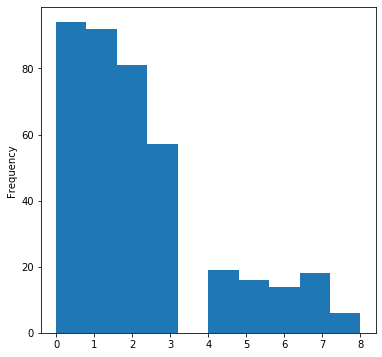

```python
new_df['behreg'].plot(kind ='hist', figsize=(6,6))
```

```python
new_df['behreg'].value_counts()
```

```
0.0    94
1.0    92
2.0    81
3.0    57
4.0    19
7.0    18
5.0    16
6.0    14
8.0     6
Name: behreg, dtype: int64
```

seperate data by gender(store in varibale girl and boy) and create a pie chart that will show the parents education with percentage

by using the .plot() function we can do so, we set parameter kind equal to 'pie', and to show percentage we set parameter autopct equal to '%1.1f%%'

figsize parameter can be set to a pair of numbers like(6,6) and it will change the size if the figure

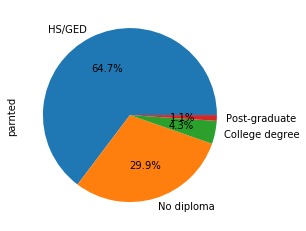

```python
girl = new_df[new_df['gender'] == 'Child gender girl']

girl['parnted'].value_counts().plot(kind = 'pie', autopct='%1.1f%%', figsize =(6,6))
```

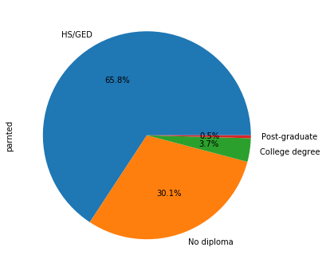

```python
boy = new_df[new_df['gender'] == 'Child gender boy']

boy['parnted'].value_counts().plot(kind = 'pie', autopct='%1.1f%%', figsize =(6,6))
```